# Investigate_a_Dataset

```python
import pandas as pd
import numpy as np
import matplotlib.pyplot as plt
%matplotlib inline
import matplotlib.pyplot as plt
```

```python
df=pd.read_csv("tmdb-movies (1).csv")
```

Explore

```python
df.head()
```

|  | id | imdb_id | popularity | budget | revenue | original_title | cast | homepage | director | tagline | ... | overview | runtime | genres | production_companies | release_date | vote_count | vote_average | release_year | budget_adj | revenue_adj |
| --- | --- | --- | --- | --- | --- | --- | --- | --- | --- | --- | --- | --- | --- | --- | --- | --- | --- | --- | --- | --- | --- |
| 0 | 135397 | tt0369610 | 32.985763 | 150000000 | 1513528810 | Jurassic World | Chris Pratt\|Bryce Dallas Howard\|Irrfan Khan\|Vi... | http://www.jurassicworld.com/ | Colin Trevorrow | The park is open. | ... | Twenty-two years after the events of Jurassic ... | 124 | Action\|Adventure\|Science Fiction\|Thriller | Universal Studios\|Amblin Entertainment\|Legenda... | 6/9/15 | 5562 | 6.5 | 2015 | 1.379999e+08 | 1.392446e+09 |
| 1 | 76341 | tt1392190 | 28.419936 | 150000000 | 378436354 | Mad Max: Fury Road | Tom Hardy\|Charlize Theron\|Hugh Keays-Byrne\|Nic... | http://www.madmaxmovie.com/ | George Miller | What a Lovely Day. | ... | An apocalyptic story set in the furthest reach... | 120 | Action\|Adventure\|Science Fiction\|Thriller | Village Roadshow Pictures\|Kennedy Miller Produ... | 5/13/15 | 6185 | 7.1 | 2015 | 1.379999e+08 | 3.481613e+08 |
| 2 | 262500 | tt2908446 | 13.112507 | 110000000 | 295238201 | Insurgent | Shailene Woodley\|Theo James\|Kate Winslet\|Ansel... | http://www.thedivergentseries.movie/#insurgent | Robert Schwentke | One Choice Can Destroy You | ... | Beatrice Prior must confront her inner demons ... | 119 | Adventure\|Science Fiction\|Thriller | Summit Entertainment\|Mandeville Films\|Red Wago... | 3/18/15 | 2480 | 6.3 | 2015 | 1.012000e+08 | 2.716190e+08 |
| 3 | 140607 | tt2488496 | 11.173104 | 200000000 | 2068178225 | Star Wars: The Force Awakens | Harrison Ford\|Mark Hamill\|Carrie Fisher\|Adam D... | http://www.starwars.com/films/star-wars-episod... | J.J. Abrams | Every generation has a story. | ... | Thirty years after defeating the Galactic Empi... | 136 | Action\|Adventure\|Science Fiction\|Fantasy | Lucasfilm\|Truenorth Productions\|Bad Robot | 12/15/15 | 5292 | 7.5 | 2015 | 1.839999e+08 | 1.902723e+09 |
| 4 | 168259 | tt2820852 | 9.335014 | 190000000 | 1506249360 | Furious 7 | Vin Diesel\|Paul Walker\|Jason Statham\|Michelle ... | http://www.furious7.com/ | James Wan | Vengeance Hits Home | ... | Deckard Shaw seeks revenge against Dominic Tor... | 137 | Action\|Crime\|Thriller | Universal Pictures\|Original Film\|Media Rights ... | 4/1/15 | 2947 | 7.3 | 2015 | 1.747999e+08 | 1.385749e+09 |

5 rows × 21 columns

```python
df.tail()
```

|  | id | imdb_id | popularity | budget | revenue | original_title | cast | homepage | director | tagline | ... | overview | runtime | genres | production_companies | release_date | vote_count | vote_average | release_year | budget_adj | revenue_adj |
| --- | --- | --- | --- | --- | --- | --- | --- | --- | --- | --- | --- | --- | --- | --- | --- | --- | --- | --- | --- | --- | --- |
| 10861 | 21 | tt0060371 | 0.080598 | 0 | 0 | The Endless Summer | Michael Hynson\|Robert August\|Lord 'Tally Ho' B... | NaN | Bruce Brown | NaN | ... | The Endless Summer, by Bruce Brown, is one of ... | 95 | Documentary | Bruce Brown Films | 6/15/66 | 11 | 7.4 | 1966 | 0.000000 | 0.0 |
| 10862 | 20379 | tt0060472 | 0.065543 | 0 | 0 | Grand Prix | James Garner\|Eva Marie Saint\|Yves Montand\|Tosh... | NaN | John Frankenheimer | Cinerama sweeps YOU into a drama of speed and ... | ... | Grand Prix driver Pete Aron is fired by his te... | 176 | Action\|Adventure\|Drama | Cherokee Productions\|Joel Productions\|Douglas ... | 12/21/66 | 20 | 5.7 | 1966 | 0.000000 | 0.0 |
| 10863 | 39768 | tt0060161 | 0.065141 | 0 | 0 | Beregis Avtomobilya | Innokentiy Smoktunovskiy\|Oleg Efremov\|Georgi Z... | NaN | Eldar Ryazanov | NaN | ... | An insurance agent who moonlights as a carthie... | 94 | Mystery\|Comedy | Mosfilm | 1/1/66 | 11 | 6.5 | 1966 | 0.000000 | 0.0 |
| 10864 | 21449 | tt0061177 | 0.064317 | 0 | 0 | What's Up, Tiger Lily? | Tatsuya Mihashi\|Akiko Wakabayashi\|Mie Hama\|Joh... | NaN | Woody Allen | WOODY ALLEN STRIKES BACK! | ... | In comic Woody Allen's film debut, he took the... | 80 | Action\|Comedy | Benedict Pictures Corp. | 11/2/66 | 22 | 5.4 | 1966 | 0.000000 | 0.0 |
| 10865 | 22293 | tt0060666 | 0.035919 | 19000 | 0 | Manos: The Hands of Fate | Harold P. Warren\|Tom Neyman\|John Reynolds\|Dian... | NaN | Harold P. Warren | It's Shocking! It's Beyond Your Imagination! | ... | A family gets lost on the road and stumbles up... | 74 | Horror | Norm-Iris | 11/15/66 | 15 | 1.5 | 1966 | 127642.279154 | 0.0 |

5 rows × 21 columns

```python
df.dtypes
```

```
id                        int64
imdb_id                  object
popularity              float64
budget                    int64
revenue                   int64
original_title           object
cast                     object
homepage                 object
director                 object
tagline                  object
keywords                 object
overview                 object
runtime                   int64
genres                   object
production_companies     object
release_date             object
vote_count                int64
vote_average            float64
release_year              int64
budget_adj              float64
revenue_adj             float64
dtype: object
```

```python
df.columns
```

```
Index(['id', 'imdb_id', 'popularity', 'budget', 'revenue', 'original_title',
       'cast', 'homepage', 'director', 'tagline', 'keywords', 'overview',
       'runtime', 'genres', 'production_companies', 'release_date',
       'vote_count', 'vote_average', 'release_year', 'budget_adj',
       'revenue_adj'],
      dtype='object')
```

```python
df.shape
```

```
(10866, 21)
```

Drop duplicates

```python
print(df.shape)
print(sum(df.duplicated()))
df.drop_duplicates(inplace = True)
print(sum(df.duplicated()))

df.shape
```

```
(10866, 21)
1
0
```

```
(10865, 21)
```

```python
print(df.isna().sum())
print(df.isna().any(axis=1).sum())
```

```
id                         0
imdb_id                   10
popularity                 0
budget                     0
revenue                    0
original_title             0
cast                      76
homepage                7929
director                  44
tagline                 2824
keywords                1493
overview                   4
runtime                    0
genres                    23
production_companies    1030
release_date               0
vote_count                 0
vote_average               0
release_year               0
budget_adj                 0
revenue_adj                0
dtype: int64
8873
```

```python
print((df.isna().any(axis=1).sum()))
```

```
8873
```

Drop useless coloumns

```python
del_columns = ['id', 'imdb_id', 'homepage', 'tagline', 'keywords', 'overview', 'release_date',
               'vote_count', 'vote_average','budget','revenue']
```

```python
df.drop(del_columns, axis= 1, inplace = True)
df.head()
```

|  | popularity | original_title | cast | director | runtime | genres | production_companies | release_year | budget_adj | revenue_adj |
| --- | --- | --- | --- | --- | --- | --- | --- | --- | --- | --- |
| 0 | 32.985763 | Jurassic World | Chris Pratt\|Bryce Dallas Howard\|Irrfan Khan\|Vi... | Colin Trevorrow | 124 | Action\|Adventure\|Science Fiction\|Thriller | Universal Studios\|Amblin Entertainment\|Legenda... | 2015 | 1.379999e+08 | 1.392446e+09 |
| 1 | 28.419936 | Mad Max: Fury Road | Tom Hardy\|Charlize Theron\|Hugh Keays-Byrne\|Nic... | George Miller | 120 | Action\|Adventure\|Science Fiction\|Thriller | Village Roadshow Pictures\|Kennedy Miller Produ... | 2015 | 1.379999e+08 | 3.481613e+08 |
| 2 | 13.112507 | Insurgent | Shailene Woodley\|Theo James\|Kate Winslet\|Ansel... | Robert Schwentke | 119 | Adventure\|Science Fiction\|Thriller | Summit Entertainment\|Mandeville Films\|Red Wago... | 2015 | 1.012000e+08 | 2.716190e+08 |
| 3 | 11.173104 | Star Wars: The Force Awakens | Harrison Ford\|Mark Hamill\|Carrie Fisher\|Adam D... | J.J. Abrams | 136 | Action\|Adventure\|Science Fiction\|Fantasy | Lucasfilm\|Truenorth Productions\|Bad Robot | 2015 | 1.839999e+08 | 1.902723e+09 |
| 4 | 9.335014 | Furious 7 | Vin Diesel\|Paul Walker\|Jason Statham\|Michelle ... | James Wan | 137 | Action\|Crime\|Thriller | Universal Pictures\|Original Film\|Media Rights ... | 2015 | 1.747999e+08 | 1.385749e+09 |

```python
df.shape
```

```
(10865, 10)
```

```python
print(df.isna().sum())
print(df.isna().any(axis=1).sum())
```

```
popularity                 0
original_title             0
cast                      76
director                  44
runtime                    0
genres                    23
production_companies    1030
release_year               0
budget_adj                 0
revenue_adj                0
dtype: int64
1093
```

Convert 0 to Na

```python
df["budget_adj"].replace(0, np.NaN, inplace = True)
df["revenue_adj"].replace(0, np.NaN, inplace = True)
df["runtime"].replace(0, np.NaN, inplace = True)
```

Drop Na

```python
df.dropna(inplace = True)
df.shape
```

```
(3805, 10)
```

```python
print(df.isna().sum())
print(df.isna().any(axis=1).sum())
```

```
popularity              0
original_title          0
cast                    0
director                0
runtime                 0
genres                  0
production_companies    0
release_year            0
budget_adj              0
revenue_adj             0
dtype: int64
0
```

Top 10 actors ,directors and genres?

```python
genres = df.genres.str.cat(sep="|").split("|")
actors = df.cast.str.cat(sep="|").split("|")
companies = df.production_companies.str.cat(sep="|").split("|")
actors_list = pd.Series(actors).value_counts()[:10]
genres_list = pd.Series(genres).value_counts()[:10]
companies_list = pd.Series(companies).value_counts()[:10]
```

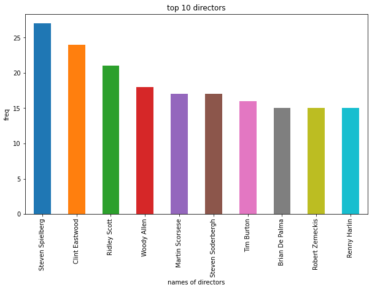

```python
df.director.value_counts()[:10].plot.bar(figsize = (10,6))
plt.title("top 10 directors")
plt.xlabel("names of directors")
plt.ylabel("freq")
```

Conculisions

Top 10 directors

Steven Spielberg,Clint Eastwood,Ridley Scott,Woody Allen,Steven Soderbergh,

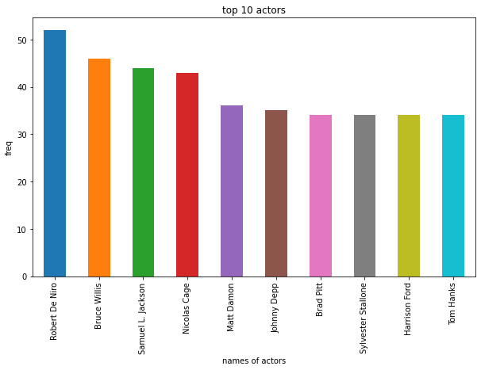

```python
actors_list.plot.bar(figsize = (10,6))
plt.title("top 10 actors")
plt.xlabel("names of actors")
plt.ylabel("freq")
```

Conculisions

Top 10 actors

Robert De Niro ,Bruce Willis ,Samuel L. Jackson ,Nicolas Cage ,Matt Damon ,

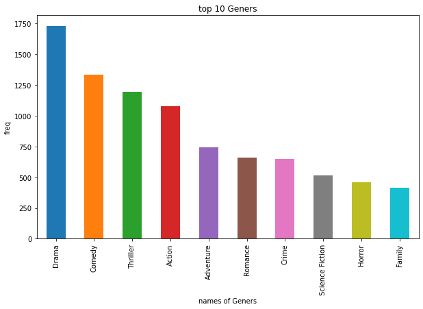

```python
genres_list.plot.bar(figsize = (10,6))
plt.title("top 10 Geners")
plt.xlabel("names of Geners")
plt.ylabel("freq")
```

Conculisions

How was change of popularity of years?

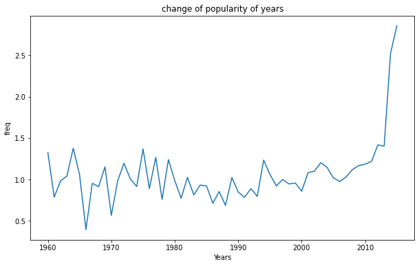

```python
changeofpopularity=df.groupby("release_year").popularity.mean()

changeofpopularity.plot(figsize = (10,6))
plt.title("change of popularity of years")
plt.xlabel("Years")
plt.ylabel("freq")
```

Conculisions

there is Obvious change in popularity over years .

check best movies genres from 2000 to 2015?

```python
sorted_genres = df[["release_year", "genres"]].sort_values(["release_year","genres"], ascending = False)
each_year_sorted_genres = pd.DataFrame(sorted_genres.groupby(["release_year"]).genres.max())
each_year_sorted_genres.tail(16)
```

| release_year | genres |
| --- | --- |
| 2000 | Thriller\|Science Fiction\|Action |
| 2001 | War |
| 2002 | Western\|Animation\|Adventure\|Comedy\|Family |
| 2003 | Western |
| 2004 | Western\|History\|War |
| 2005 | Thriller\|Science Fiction\|Adventure\|Action |
| 2006 | Western\|Drama |
| 2007 | Western |
| 2008 | War\|Drama |
| 2009 | Thriller\|Science Fiction |
| 2010 | Thriller\|Mystery |
| 2011 | War\|Drama |
| 2012 | War\|Action\|Thriller\|Science Fiction |
| 2013 | Western\|Thriller |
| 2014 | Western\|Drama |
| 2015 | Western\|Drama\|Adventure\|Thriller |

Conculisions

what is highest and lowest profit for movie?

```python
df["prof"] = df["revenue_adj"] - df["budget_adj"]

i=df.prof.idxmax()
print("highest profit")
print(df.original_title.loc[i])
print(df.prof.loc[i])
ii=df.prof.idxmin()
print("least profit")
print(df.original_title.loc[ii])
print(df.prof.loc[ii])
```

```
highest profit
Star Wars
2750136650.919176
least profit
The Warrior's Way
-413912431.0
```

Conculisions

highest movie profit Star Wars with 2750136650.919176.

least movie profit The Warrior's Way with -413912431.0.

longest and shortest runtime movie?

```python
max_runtime=df.runtime.idxmax()
min_runtime=df.runtime.idxmin()
```

```python
print("longest runtime is")
print(df.original_title.loc[max_runtime])
print(df.runtime.loc[max_runtime])
print("shortest runtime is")
print(df.original_title.loc[min_runtime])
print(df.runtime.loc[min_runtime])
```

```
longest runtime is
Carlos
338.0
shortest runtime is
Kid's Story
15.0
```

Conculisions

longest runtime movie is Carlos 338.0 min.

shortest runtime is Kid's Story 15.0 min .

most and lowest popularity movie?

```python
demo=df.popularity.idxmax()
demo1=df.popularity.idxmin()

print("most popularity movie is ",df.original_title.loc[demo])
print("least popularity movie is ",df.original_title.loc[demo1])
```

[output not shown]

Conculisions

most popularity movie is Jurassic World.

Average profit of movies from 2000 to 2015? and highest average year?

```python
temp=pd.DataFrame(df.groupby(["release_year"]).prof.mean())
temp2=temp.tail(16)
temp.tail(16)
temp2=temp2.reset_index()
temp2
```

|  | release_year | prof |
| --- | --- | --- |
| 0 | 2000 | 7.409581e+07 |
| 1 | 2001 | 8.330996e+07 |
| 2 | 2002 | 8.716851e+07 |
| 3 | 2003 | 9.014710e+07 |
| 4 | 2004 | 7.987922e+07 |
| 5 | 2005 | 6.520897e+07 |
| 6 | 2006 | 5.614571e+07 |
| 7 | 2007 | 7.738606e+07 |
| 8 | 2008 | 7.399089e+07 |
| 9 | 2009 | 8.416242e+07 |
| 10 | 2010 | 7.539550e+07 |
| 11 | 2011 | 7.404984e+07 |
| 12 | 2012 | 1.002128e+08 |
| 13 | 2013 | 8.255162e+07 |
| 14 | 2014 | 9.309273e+07 |
| 15 | 2015 | 1.094348e+08 |

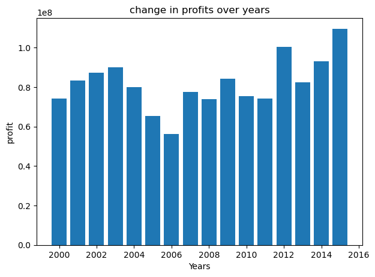

```python
plt.rcParams.update({'figure.figsize':(7,5), 'figure.dpi':100})
plt.bar(temp2.release_year,temp2.prof)
plt.title("change in profits over years")
plt.xlabel("Years")
plt.ylabel("profit")
```

```python
highest_average_pro=temp2.prof.idxmax()
print("highest average profit  year",temp2.release_year.loc[highest_average_pro])
```

```
highest average profit  year 2015
```

best comedy actor ?

```python
df2=df[df.genres.str.contains(pat="Comedy")]
actors2 = df2.cast.str.cat(sep="|").split("|")
actors_list2 = pd.DataFrame(pd.Series(actors2).value_counts()[:10])
actors_list2=actors_list2.reset_index()
print("best comedy actor is ",actors_list2["index"][0])
```

```
best comedy actor is  Eddie Murphy
```

Conculisions

best comedy actor is Eddie Murphy

Conculisions Top 10 directors

Steven Spielberg,Clint Eastwood,Ridley Scott,Woody Allen,Steven Soderbergh,

Top 10 actors

Robert De Niro ,Bruce Willis ,Samuel L. Jackson ,Nicolas Cage ,Matt Damon ,

there is Obvious change in popularity over years .

highest movie profit Star Wars with 2750136650.919176.

least movie profit The Warrior's Way with -413912431.0.

longest runtime movie is Carlos 338.0 min.

shortest runtime is Kid's Story 15.0 min .

most popularity movie is Jurassic World.

highest average profit year 2015.

best comedy actor is Eddie Murphy.

Limitation:

The dataset contains a huge amount of 0 and NaN values so i drop over 6000 movies.which can mislead final results.

i drop some columns that are not useful in my mind :-

[id,imdb_id,homepage,tagline,keywords,overview,release_date,vote_count,vote_average,budget,revenue]

I use (budget_adj, revenue_adj) columns to account for profit over time, if (budget, revenue) columns are used different results will appear.